# Impact of a malaria elimination on school outcomes

August 21, 2017

# Introduction

Malaria poses a double threat to children. First, they are vulnerable to the physiological effects of the illness, including death (as many as 50% of deaths among school-aged children in areas of Africa can be attributed to malaria (Murray et al., 2012)). Second, the social and economic impact of malaria infection in children has a more reverberating effect than among adults: a missed day of work affects short-term wages; a missed day of school affects long-term human capital accumulation (Bleakley, 2010), and shocks in health to young people have been shown to have drastic effects later in life (Smith, 2009, Case and Paxson (2011), Currie et al. (2008)).

Though children are recognized as a group of importance in terms of malaria and its effects, little is known about the educational impact of malaria control and elimination programs. Studies which do exist suggest that the reduction of malaria is associated with an improvement in cognitive ability, and a reduction in absenteeism (Lucas, 2010, Sachs and Malaney (2002)). However, these studies generally rely on secondary information, using natural variation in malarial incidence, rather than shocks or interventions. Those studies which do examine the effect of interventions are generally either (a) relatively small in sample, or (b) very historical (with a focus on the WHO’s 1950s and 1960s GMEP). (Need more references here) Given the current global push towards malaria eradication (Alonso et al., 2011), quantifying the extent to which programmes aimed at malaria elimination improve educational outcomes (absenteeism and performance) relative to traditional “control” strategies is essential.

## Context

This study’s objective was to measure the educational impact of a malaria elimination campaign in Southern Mozambique. This campaign, which saw the massive administration of 4 rounds of dihydroartemisinin-piperaquine along with accompanying indoor residual spraying and reactive epidemiological surveillance activities, has been described in detail elsewhere (F et al., 2017). Figure 1 shows the intervention (Magude) and control (Manhiça) districts, along with the location of residences (red) and schools (black).

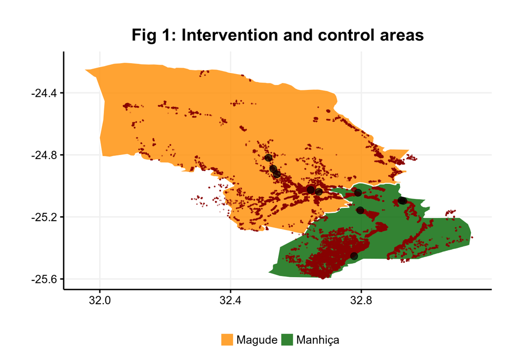

## Literature

```r
cat(paste0("[@Grant2013]"))
```

For example, evidence from rural Malawi suggests that menstruation plays a significant role in absenteeism (Grant et al., 2013).

## Ethics

The protocol for this study was approved by the scientific and ethics committees of the Centro de Investigação em Saude de Manhiça.

# Methods

## Data cleaning

Data were inconsistently coded, particularly in terms of spelling. This was a function of (a) data entry error on the part of the schools which maintain the records, (b) data entry error on the part of the clerks hired for this project, and (c) variation in how names are used in Mozambique (middle name vs. mother’s last name, vs father’s last name, etc.). To address these inconsistencies, we used three different approaches to identifying “matches” (ie, differently coded data elements which were actually from the same source): (i) fuzzy-matching using approximate string distance, (ii) the “OpenRefine” software, and (iii) manual checks and modifications.

A secondary issue we faced in the data cleaning process was the falsification of data on the part of the teachers who maintained absenteeism records. In some cases, an entire class of 30 students was marked as “present” for months consecutively, something which was almost certainly not the case. In order to identify and remove from our sample consecutive chains of absences and presences which we determined to be unbelievable, we estimated the probability of each chain’s occurrence given a prior, independent day-specific absenteeism rate of 8%, and removed those chains of presences and absences with probabilities below 0.0001 and 0.00001, respectively (we’ll need to change these figures later).

## Analysis

We employ a two step analysis for the estimation of the effect of the intervention on student absenteeism and performance. First, we construct an ordinary least squares regression model, controlling for potential confounders and interacting binary varibles for time and place to parse the adjusted effect of the intervention on both performance and absenteeism at the global level (ie, aggregate rates before and after). Second, we construct an “event study model” at the trimester level to detect the shock from the intervention itself, and to estimate the differential nature and signifiance of absenteeism and performance trends in both regions.

# Results

We observed a total of 193,233 unique student-days from Magude (intervention area) and 417,956 from Manhiça (control area). We also collected the standardized test scores for 57,372 and 157,303 unique trimester-student-subjects, respectively for the two districts.

Though are sample was significantly smaller in Magude, the two groups are fairly similar in terms of demographics (see below table).

| Characteristic | Manhiça | Magude |
| --- | --- | --- |
| Age mean | 9.37 | 9.16 |
| age SD | 2.71 | 2.78 |
| conditions score SD | 3986.16 | 4150.42 |
| Education mean | 2.38 | 2.53 |
| education SD | 1.16 | 1.46 |
| Females | 2352.00 | 750.00 |
| Males | 2445.00 | 708.00 |
| N | 6191.00 | 2612.00 |
| Ses asset score mean | 6976.67 | 6752.86 |
| ses asset score SD | 971.98 | 805.78 |
| Siblings mean | 4.49 | 4.40 |
| siblings SD | 2.53 | 2.84 |

The average annual absenteeism rates in the two districts ranged from 8.53 to 11.03. The average grade, which is on a 0-20 scale, ranged from 12.15 to 12.51 (see below table).

| District | Year | Absenteeism rate | Average grade |
| --- | --- | --- | --- |
| Magude | 2015 | 11.03 | 12.15 |
| Magude | 2016 | 8.92 | 12.51 |
| Manhiça | 2015 | 8.91 | 12.28 |
| Manhiça | 2016 | 8.53 | 12.46 |

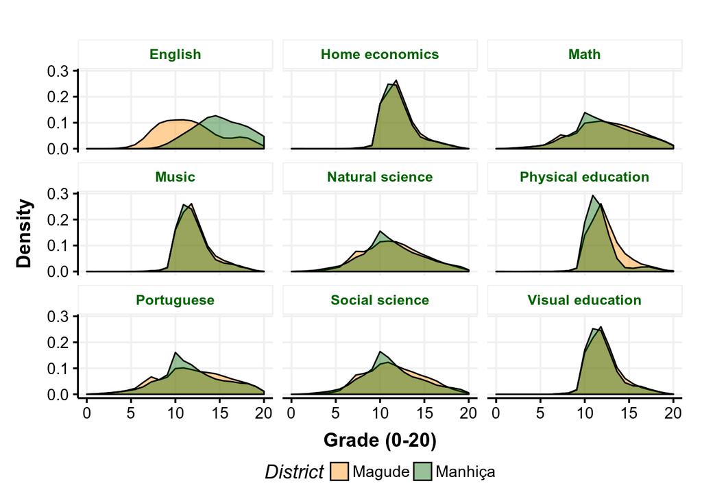

The below chart shows the percentage of student-trimester-subject matches which received a “passing” (> 10) mark by year and district. Note the much steeper improvement in Magude, relative to Manhiça.

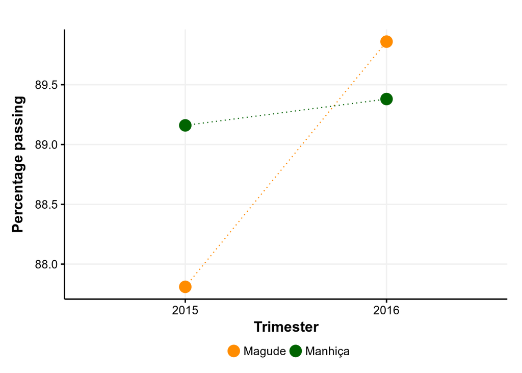

The below chart shows the average mark by year and district. Again, though both districts saw improvements, note the much more pronounced improvement in Magude relative to Manhiça.

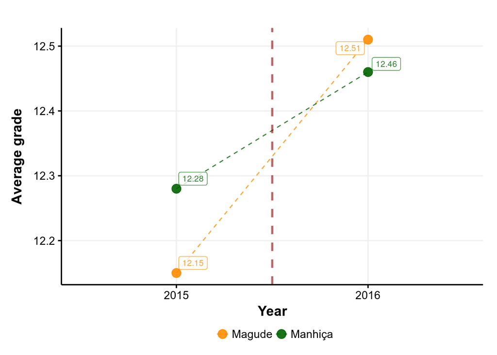

The below chart shows the average absenteeism rate, per trimester, for each school.

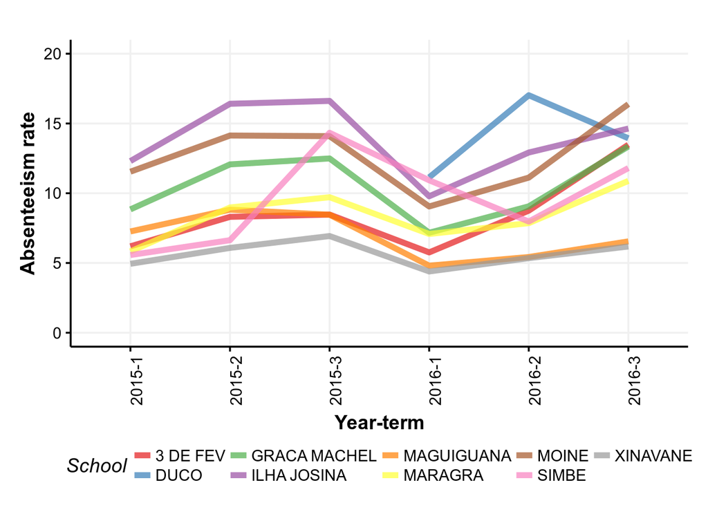

Below shows absenteeism at the district level.

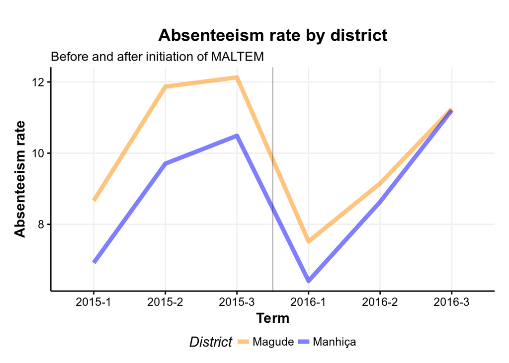

If we aggregate at the year level….

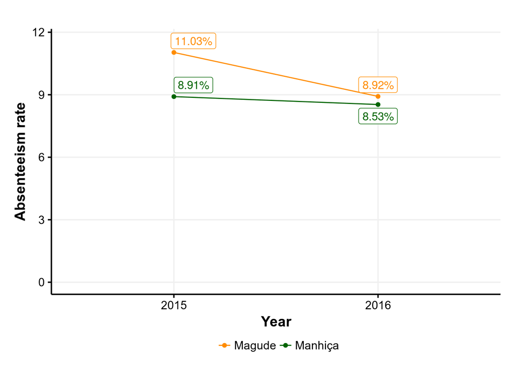

## Difference in differences

The below table shows the regression details for three different models, all using the binary outcome of passed vs. did-not-pass, and right hand side variables representing binary time (before vs. after), binary location (interventin vs. control), and the fixed effect of the school. Models 2 and 3 also include the school subject, and model 3 includes fixed effects for trimester.

| Term | Key | 1 | 2 | 3 |
| --- | --- | --- | --- | --- |
| After | Estimate | 0.004 | 0.004 | 0.004 |
|  | P | 0.021 | 0.004 | 0.004 |
|  | S.E. | 0.002 | 0.001 | 0.001 |
| After:Intervention | Estimate | 0.016 | 0.017 | 0.017 |
|  | P | < 0.001 | < 0.001 | < 0.001 |
|  | S.E. | 0.003 | 0.003 | 0.003 |
| (Intercept) | Estimate | 0.867 | 0.754 | 0.755 |
|  | P | < 0.001 | < 0.001 | < 0.001 |
|  | S.E. | 0.002 | 0.026 | 0.026 |
| Intervention | Estimate | 0.047 | 0.039 | 0.039 |
|  | P | < 0.001 | < 0.001 | < 0.001 |
|  | S.E. | 0.005 | 0.005 | 0.005 |

The below is a reproduction of the above, but only for mathematics (excluding all other subject tests).

| Term | Key | value |
| --- | --- | --- |
| After | Estimate | 0.008 |
|  | S.E. | 0.005 |
|  | P | 0.151 |
| factor(trimester)2 | Estimate | < 0.001 |
|  | S.E. | 0.005 |
|  | P | 0.007 |
| factor(trimester)3 | Estimate | < 0.001 |
|  | S.E. | 0.006 |
|  | P | < 0.001 |
| After:Intervention | Estimate | 0.047 |
|  | S.E. | 0.01 |
|  | P | < 0.001 |
| (Intercept) | Estimate | 0.784 |
|  | S.E. | 0.007 |
|  | P | < 0.001 |
| Intervention | Estimate | 0.029 |
|  | S.E. | 0.018 |
|  | P | 0.105 |

We can also regress the *average grade* (rather than the binary pass/fail), as shown in the below.

| Term | Key | 1 | 2 | 3 |
| --- | --- | --- | --- | --- |
| After | Estimate | 0.198 | 0.201 | 0.201 |
|  | P | < 0.001 | < 0.001 | < 0.001 |
|  | S.E. | 0.014 | 0.014 | 0.014 |
| After:Intervention | Estimate | 0.166 | 0.173 | 0.173 |
|  | P | < 0.001 | < 0.001 | < 0.001 |
|  | S.E. | 0.027 | 0.027 | 0.027 |
| (Intercept) | Estimate | 11.832 | 11.945 | 11.934 |
|  | P | < 0.001 | < 0.001 | < 0.001 |
|  | S.E. | 0.015 | 0.248 | 0.248 |
| Intervention | Estimate | 0.029 | < 0.001 | < 0.001 |
|  | P | 0.55 | 0.62 | 0.62 |
|  | S.E. | 0.048 | 0.047 | 0.047 |

Again, we reproduce the above for mathematics only (average, continuous grade)

| Term | Key | value |
| --- | --- | --- |
| After | Estimate | 0.196 |
|  | S.E. | 0.047 |
|  | P | < 0.001 |
| factor(trimester)2 | Estimate | < 0.001 |
|  | S.E. | 0.048 |
|  | P | < 0.001 |
| factor(trimester)3 | Estimate | < 0.001 |
|  | S.E. | 0.049 |
|  | P | < 0.001 |
| After:Intervention | Estimate | 0.408 |
|  | S.E. | 0.09 |
|  | P | < 0.001 |
| (Intercept) | Estimate | 12.093 |
|  | S.E. | 0.059 |
|  | P | < 0.001 |
| Intervention | Estimate | < 0.001 |
|  | S.E. | 0.159 |
|  | P | 0.01 |

## Event study

The below shows the regression outputs for our event study model.

| Term | Key | value |
| --- | --- | --- |
| (Intercept) | Estimate | 0.734 |
|  | Estimate | 0.056 |
| -1 Period | Estimate | < 0.001 |
| 1 Period | Estimate | 0.005 |
| -2 Period | Estimate | < 0.001 |
| 2 Period | Estimate | < 0.001 |
| -3 Period | Estimate | 0.001 |
| 0 Time::Intervention | Estimate | 0.023 |
| -1 Time::Intervention | Estimate | 0.011 |
| 1 Time::Intervention | Estimate | 0.022 |
| -2 Time::Intervention | Estimate | 0.006 |
| 2 Time::Intervention | Estimate | 0.023 |

As with OLS, we run the same model, but only for mathematics.

| Term | Key | value |
| --- | --- | --- |
| (Intercept) | Estimate | 0.711 |
|  | S.E. | 0.021 |
|  | P | < 0.001 |
|  | Estimate | 0.087 |
|  | S.E. | 0.02 |
|  | P | < 0.001 |
| -1 Period | Estimate | < 0.001 |
|  | S.E. | 0.009 |
|  | P | 0.004 |
| 1 Period | Estimate | 0.001 |
|  | S.E. | 0.009 |
|  | P | 0.888 |
| -2 Period | Estimate | < 0.001 |
|  | S.E. | 0.009 |
|  | P | 0.022 |
| 2 Period | Estimate | < 0.001 |
|  | S.E. | 0.009 |
|  | P | 0.206 |
| -3 Period | Estimate | 0.014 |
|  | S.E. | 0.009 |
|  | P | 0.129 |
| 0 Time::Intervention | Estimate | 0.071 |
|  | S.E. | 0.017 |
|  | P | < 0.001 |
| -1 Time::Intervention | Estimate | 0.021 |
|  | S.E. | 0.019 |
|  | P | 0.249 |
| 1 Time::Intervention | Estimate | 0.062 |
|  | S.E. | 0.018 |
|  | P | < 0.001 |
| -2 Time::Intervention | Estimate | 0.016 |
|  | S.E. | 0.018 |
|  | P | 0.373 |
| 2 Time::Intervention | Estimate | 0.046 |
|  | S.E. | 0.018 |
|  | P | 0.009 |

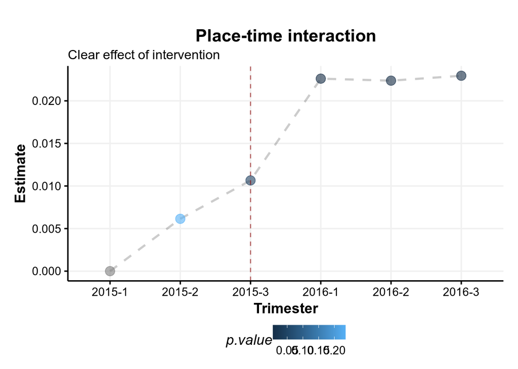

## Absenteeism analysis

For our analysis of absenteeism, we construct a binomial logistic regression to estimate the odds or absence as a function of the intervention (interaction of time and place), along with the same potential confounders previously mentioned (excluding subject, which is no longer applicable).

### Simple logistic

The below shows the output of a simple binomial logistic regression for the overal (not trimester-specific) effect of the intervention.

| term | estimate | std.error | or | lwr | upr | p.value |
| --- | --- | --- | --- | --- | --- | --- |
| (Intercept) | 0.080 | 0.001 | 1.083 | 1.081 | 1.085 | 0.000 |
| intervention | 0.025 | 0.003 | 1.025 | 1.020 | 1.031 | 0.000 |
| interv_afterTRUE | -0.026 | 0.001 | 0.974 | 0.972 | 0.977 | 0.000 |
| schoolDUCO | 0.073 | 0.003 | 1.076 | 1.069 | 1.082 | 0.000 |
| schoolGRACA MACHEL | 0.010 | 0.003 | 1.010 | 1.004 | 1.015 | 0.000 |
| schoolILHA JOSINA | 0.060 | 0.001 | 1.062 | 1.059 | 1.065 | 0.000 |
| schoolMAGUIGUANA | -0.021 | 0.003 | 0.979 | 0.974 | 0.985 | 0.000 |
| schoolMARAGRA | 0.002 | 0.001 | 1.002 | 0.999 | 1.004 | 0.176 |
| schoolMOINE | 0.032 | 0.003 | 1.032 | 1.025 | 1.039 | 0.000 |
| schoolXINAVANE | -0.024 | 0.001 | 0.976 | 0.974 | 0.979 | 0.000 |

**Adjusted for school, the overall effect of the intervention was the reduction in the odds of absence by 2.6% (95% confidence interval of 2.3 % to 2.8%).**

### Event study

The below shows the output of our binomial logistic regression for event study.

| term | estimate | std.error | or | lwr | upr | p.value |
| --- | --- | --- | --- | --- | --- | --- |
| (Intercept) | 0.079 | 0.003 | 1.082 | 1.076 | 1.087 | 0.000 |
| intervention | -0.003 | 0.003 | 0.997 | 0.990 | 1.003 | 0.324 |
| period-2 | 0.027 | 0.001 | 1.027 | 1.025 | 1.030 | 0.000 |
| period-1 | 0.032 | 0.002 | 1.033 | 1.029 | 1.036 | 0.000 |
| period0 | -0.001 | 0.002 | 0.999 | 0.995 | 1.002 | 0.355 |
| period1 | 0.017 | 0.001 | 1.017 | 1.014 | 1.020 | 0.000 |
| period2 | 0.042 | 0.002 | 1.043 | 1.039 | 1.046 | 0.000 |
| timetreat-2 | 0.010 | 0.003 | 1.010 | 1.004 | 1.015 | 0.000 |
| timetreat-1 | 0.006 | 0.003 | 1.006 | 1.000 | 1.013 | 0.056 |
| timetreat0 | -0.015 | 0.003 | 0.985 | 0.979 | 0.990 | 0.000 |
| timetreat1 | -0.014 | 0.003 | 0.986 | 0.981 | 0.991 | 0.000 |
| timetreat2 | -0.016 | 0.003 | 0.984 | 0.978 | 0.990 | 0.000 |
| schoolDUCO | 0.079 | 0.003 | 1.083 | 1.076 | 1.090 | 0.000 |
| schoolGRACA MACHEL | 0.014 | 0.003 | 1.015 | 1.009 | 1.020 | 0.000 |
| schoolILHA JOSINA | 0.058 | 0.001 | 1.060 | 1.057 | 1.063 | 0.000 |
| schoolMAGUIGUANA | -0.022 | 0.003 | 0.979 | 0.973 | 0.984 | 0.000 |
| schoolMARAGRA | 0.000 | 0.001 | 1.000 | 0.998 | 1.003 | 0.786 |
| schoolMOINE | 0.034 | 0.003 | 1.035 | 1.028 | 1.042 | 0.000 |
| schoolXINAVANE | -0.026 | 0.001 | 0.974 | 0.972 | 0.977 | 0.000 |

Below is a visualization of the effect of the interaction of time and place (a replication of event-study, but specifically for odds ratios for absence).

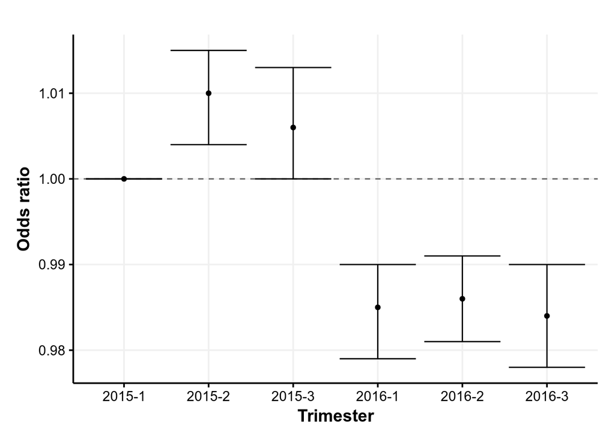

# Discussion / Conclusion

# References

Alonso, P.L., Brown, G., Arevalo-Herrera, M., Binka, F., Chitnis, C., Collins, F., Doumbo, O.K., Greenwood, B., Hall, B.F., Levine, M.M., Mendis, K., Newman, R.D., Plowe, C.V., Rodríguez, M.H., Sinden, R., Slutsker, L., Tanner, M., 2011. A research agenda to underpin malaria eradication. PLoS Medicine 8, e1000406. doi:10.1371/journal.pmed.1000406

Bleakley, H., 2010. Health, human capital, and development. Annual Review of Economics 2, 283–310. doi:10.1146/annurev.economics.102308.124436

Case, A., Paxson, C., 2011. The long reach of childhood health and circumstance: Evidence from the whitehall II study*. Econ. J. Nepal 121, F183–F204.

Currie, J., Stabile, M., Manivong, P., Roos, L., 2008. Child health and young adult outcomes.

Grant, M., Lloyd, C., Mensch, B., 2013. Menstruation and school absenteeism: Evidence from rural malawi. Comparative Education Review 57, 260–284. doi:10.1086/669121

Lucas, A.M., 2010. Malaria eradication and educational attainment: Evidence from paraguay and sri lanka. Am. Econ. J. Appl. Econ. 2, 46–71.

Murray, C.J., Rosenfeld, L.C., Lim, S.S., Andrews, K.G., Foreman, K.J., Haring, D., Fullman, N., Naghavi, M., Lozano, R., Lopez, A.D., 2012. Global malaria mortality between 1980 and 2010: A systematic analysis. The Lancet 379, 413–431. doi:10.1016/s0140-6736(12)60034-8

Sachs, J., Malaney, P., 2002. The economic and social burden of malaria. Nature 415, 680–685.

Smith, J.P., 2009. The impact of childhood health on adult labor market outcomes. Rev. Econ. Stat. 91, 478–489.